# **Movie Recommendation System**

## **1. Project Objective**

All entertainment websites or online stores have millions/billions of items. It becomes challenging for the customer to select the right one. At this place, recommender systems come into the picture and help the user to find the right item by minimizing the options.

Recommendation Systems in the world of machine learning have become very popular and are a huge advantage to tech giants like Netflix, Amazon and many more to target their content to a specific audience. These recommendation engines are so strong in their predictions that they can dynamically alter the state of what the user sees on their page based on the user’s interaction with the app.

## **2. Data Collection**

The dataset has been obtained from Grouplens.

Link : https://grouplens.org/datasets/movielens/20m/

This dataset (ml-20m) describes 5-star rating and free-text tagging activity from MovieLens, a movie recommendation service. It contains 20000263 ratings and 465564 tag applications across 27278 movies. These data were created by 138493 users between January 09, 1995 and March 31, 2015. This dataset was generated on October 17, 2016.

Users were selected at random for inclusion. All selected users had rated at least 20 movies. No demographic information is included. Each user is represented by an id, and no other information is provided.

The data are contained in the files genome-scores.csv, genome-tags.csv, links.csv, movies.csv, ratings.csv and tags.csv.

For our objective, we would be using "ratings.csv" and "movies.csv" data files.

```python
# Importing the necessary libraries

import numpy as np
import pandas as pd
import matplotlib
import matplotlib.pyplot as plt
import seaborn as sns

import warnings
warnings.filterwarnings("ignore")
```

## **3. Data Preparation/Preprocessing**

We will start with loading and familiarizing with the dataset so that we can prepare the data for Machine Learning (ML) modelling.

```python
file_path = r"C:\Users\Hyma vathi\Desktop\Movie-Recommendation-System-main"

movie_ratings = pd.read_csv(file_path + "/ratings.csv")
movies = pd.read_csv(file_path + "/movies.csv")
```

```python
# Creating a newId for every movie to reduce the range of existing movieId

movies["newId"] = range(1, movies["movieId"].nunique()+1)
```

```python
import pandas as pd
from datetime import datetime

# File path to datasets
file_path = r"C:\Users\Hyma vathi\Desktop\Movie-Recommendation-System-main"

# Load the datasets
try:
    movie_ratings = pd.read_csv(file_path + r"\ratings.csv")
    movies = pd.read_csv(file_path + r"\movies.csv")
except FileNotFoundError as e:
    print(f"File not found: {e}")
except Exception as e:
    print(f"An error occurred: {e}")
```

```python
import pandas as pd
from datetime import datetime

# Load datasets
file_path = r"C:\Users\Hyma vathi\Desktop\Movie-Recommendation-System-main"
movie_ratings = pd.read_csv(file_path + r"\ratings.csv")
movies = pd.read_csv(file_path + r"\movies.csv")

# Ensure 'newId' exists or create it
if "newId" not in movie_ratings.columns:
    movie_ratings["newId"] = movie_ratings["movieId"]

if "newId" not in movies.columns:
    movies["newId"] = movies["movieId"]

# Convert 'timestamp' to 'date'
if "timestamp" in movie_ratings.columns:
    movie_ratings["date"] = movie_ratings["timestamp"].apply(
        lambda x: datetime.utcfromtimestamp(x).strftime("%Y-%m-%d")
    )
else:
    print("'timestamp' column not found in movie_ratings.")

# Drop 'newId'
movie_ratings.drop(["newId"], axis=1, inplace=True)
movies.drop(["newId"], axis=1, inplace=True)

# Sort by 'date'
if "date" in movie_ratings.columns:
    movie_ratings.sort_values(by="date", inplace=True)
    movie_ratings.reset_index(drop=True, inplace=True)
else:
    print("'date' column not found in movie_ratings.")

# Display results
print(movie_ratings.head())
print(movies.head())
```

```python
# Checking the features and no. of records in the dataset

print("The number of records are : ", movie_ratings.shape[0])
print("The number of features are : ", movie_ratings.shape[1])
print("The list of features is : ", movie_ratings.columns)
movie_ratings.head()
```

[output not shown]

### **3.1 Data Cleaning**

We will begin with data cleaning such that we can handle missing values, outliers, rare values and drop the unnecessary features that do not carry useful information.

```python
# Checking for duplicates

print("No. of duplicates records in the dataset : ", movie_ratings.columns.duplicated().sum())
```

```
No. of duplicates records in the dataset :  0
```

```python
# Checking the columns' titles and datatypes

movie_ratings.info()
```

```
<class 'pandas.core.frame.DataFrame'>
RangeIndex: 20000263 entries, 0 to 20000262
Data columns (total 5 columns):
 #   Column     Dtype
---  ------     -----
 0   userId     int64
 1   movieId    int64
 2   rating     float64
 3   timestamp  int64
 4   date       object
dtypes: float64(1), int64(3), object(1)
memory usage: 762.9+ MB
```

#### **3.1.1 Handling Missing Values**

Identifying the features that have some missing values and imputing them.

```python
# Checking the number of missing values in data

movie_ratings.isna().sum()
```

```
userId       0
movieId      0
rating       0
timestamp    0
date         0
dtype: int64
```

Observations:

1. It looks like that the dataset is well maintained as we do not see any missing values, which is good.

### **3.2 Exploratory Data Analysis**

After the data cleaning steps, we can now perform EDA on the dataset to discover patterns and relationships that will help in understanding the data better.

#### **3.2.1 Univariate Analysis**

Analyzing each feature inidividually to gain insights from the data and discover any outliers.

```python
import numpy as np

# Checking the feature "userID"
total_users = len(np.unique(movie_ratings["userId"]))
print("The count of unique userID in the dataset is : ", total_users)
print("The top 5 userID in the dataset are : \n", movie_ratings["userId"].value_counts()[:5])
```

```
The count of unique userID in the dataset is :  138493
The top 5 userID in the dataset are :
 userId
118205    9254
8405      7515
82418     5646
121535    5520
125794    5491
Name: count, dtype: int64
```

Observations:

1. "userId" are the Users that were selected at random for inclusion and their ids have been anonymized.
2. There are 138K+ unique users in the dataset.
3. userId 118205 has around 9K records in the dataset.

```python
# Checking the feature "movieID"

total_movies = len(np.unique(movie_ratings["movieId"]))
print("The count of unique movieID in the dataset is : ", total_movies)
print("The top 5 movieID in the dataset are : \n", movie_ratings["movieId"].value_counts()[:5])
```

```
The count of unique movieID in the dataset is :  26744
The top 5 movieID in the dataset are :
 movieId
296    67310
356    66172
318    63366
593    63299
480    59715
Name: count, dtype: int64
```

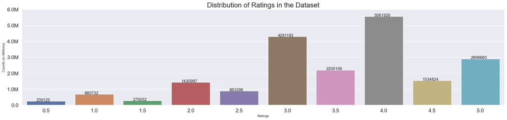

```python
import seaborn as sns
import matplotlib.pyplot as plt

# Define the custom label formatter if not already defined
def changingLabels(num):
    if num >= 1e6:
        return f'{num / 1e6:.1f}M'
    elif num >= 1e3:
        return f'{num / 1e3:.1f}K'
    return str(num)

# Checking the feature "rating"
sns.set(style="darkgrid")
fig, axes = plt.subplots(1, 1, figsize=(25, 5), sharey=True)

# Plot the countplot
sns.countplot(x="rating", data=movie_ratings, ax=axes)

# Set ticks and their labels explicitly
yticks = axes.get_yticks()  # Retrieve y-tick positions
axes.set_yticks(yticks)  # Explicitly set the same positions
axes.set_yticklabels([changingLabels(num) for num in yticks])  # Format the labels

# Annotate the bars with counts
for p in axes.patches:
    axes.annotate(f'{int(p.get_height())}', (p.get_x() + 0.2, p.get_height() + 100), fontsize=12)

# Adjust plot labels and title
plt.tick_params(labelsize=15)
plt.title("Distribution of Ratings in the Dataset", fontsize=20)
plt.xlabel("Ratings", fontsize=10)
plt.ylabel("Counts (in Millions)", fontsize=10)
plt.show()
```

Observations:

1. The ratings given by users to movies lies in between 0.5 to 5.
2. A high proportion of the movies have been rated 3, 3.5 or 4 by the users.
3. The distribution of ratings look a bit left skewed as large proportion of ratings is in between 3 to 5.

```python
# Checking the feature "date"

print("The count of unique date in the dataset is : ", movie_ratings["date"].nunique())
print("The first rating was given on : ", movie_ratings["date"].min())
print("The latest rating was given on : ", movie_ratings["date"].max())
print("The top 5 date in the dataset are : \n", movie_ratings["date"].value_counts()[:5])
```

```
The count of unique date in the dataset is :  6911
The first rating was given on :  1995-01-09
The latest rating was given on :  2015-03-31
The top 5 date in the dataset are :
 date
2000-11-20    91753
2005-03-22    76568
1999-12-11    65077
2008-10-29    55163
2000-11-21    54131
Name: count, dtype: int64
```

Observations:

1. There are ~7K unique dates when the ratings were given by a user to a movie.
2. The first rating was given on 1995-01-09 and the latest rating was given on 2015-03-31.
3. Around 91K+ ratings were observed on 2000-11-20.

```python
# Checking the feature "title" from the movies DataFrame
movie_list = movies["title"].unique()
print("The count of unique titles in the dataset is : ", movies["title"].nunique())
print("The top 5 titles in the dataset are : \n", movies["title"].value_counts()[:5])
```

```
The count of unique titles in the dataset is :  27262
The top 5 titles in the dataset are :
 title
Aladdin (1992)                         2
Johnny Express (2014)                  2
Chaos (2005)                           2
Hamlet (2000)                          2
20,000 Leagues Under the Sea (1997)    2
Name: count, dtype: int64
```

Observations:

1. There are 26K+ unique movie titles in the dataset.
2. Pulp Fiction, Forrest Gump, Shawshank Redemption and Silence of the Lambs are the top 4 movies in terms of no. of ratings received which are over 60K+ for each one.

```python
# Extract unique Genres along with their count
unique_genres = {}

def ExtractGenres(x):
    for g in x.split("|"):
        if g not in unique_genres.keys():
            unique_genres[g] = 1
        else:
            unique_genres[g] = unique_genres[g] + 1

# Apply the function to the 'genres' column in the 'movies' DataFrame
movies["genres"].apply(ExtractGenres)

# Print the extracted genres count
print("Genres Extracted from the dataset.")
print(unique_genres)
```

```
Genres Extracted from the dataset.
{'Adventure': 2329, 'Animation': 1027, 'Children': 1139, 'Comedy': 8374, 'Fantasy': 1412, 'Romance': 4127, 'Drama': 13344, 'Action': 3520, 'Crime': 2939, 'Thriller': 4178, 'Horror': 2611, 'Mystery': 1514, 'Sci-Fi': 1743, 'IMAX': 196, 'Documentary': 2471, 'War': 1194, 'Musical': 1036, 'Western': 676,…
```

[figure not shown]

```python
import matplotlib.pyplot as plt
import seaborn as sns
import pandas as pd

# Sample data
unique_genres = {'Action': 10, 'Drama': 15, 'Comedy': 7, 'Horror': 4}
genres_df = pd.DataFrame(list(unique_genres.items()))
genres_df.columns = ["Genre", "Count"]

# Function to modify y-tick labels (sample implementation)
def changingLabels(num):
    return f'{int(num)}M'

sns.set(style="darkgrid")
fig, axes = plt.subplots(1, 1, figsize=(25, 8), sharey=True)

sns.barplot(y="Count", x="Genre", data=genres_df, ax=axes)
axes.set_yticks(axes.get_yticks())  # Set y-ticks positions explicitly
axes.set_yticklabels([changingLabels(num) for num in axes.get_yticks()])

for p in axes.patches:
    axes.annotate('{}'.format(int(p.get_height())), (p.get_x(), p.get_height()+0.5))

plt.tick_params(labelsize=15)
plt.title("Distribution of Genres in the dataset", fontsize=20)
plt.xlabel("Genres", fontsize=15)
plt.xticks(rotation=60, fontsize=10)
plt.yticks(fontsize=10)
plt.ylabel("Counts (in Millions)", fontsize=15)
plt.show()
```

```python
movie_ratings.head()
```

|  | userId | movieId | rating | timestamp | date |
| --- | --- | --- | --- | --- | --- |
| 0 | 131160 | 1079 | 3.0 | 789652009 | 1995-01-09 |
| 1 | 131160 | 47 | 5.0 | 789652009 | 1995-01-09 |
| 2 | 28507 | 1176 | 4.0 | 789652004 | 1995-01-09 |
| 3 | 131160 | 21 | 3.0 | 789652009 | 1995-01-09 |
| 4 | 85252 | 7 | 5.0 | 822873600 | 1996-01-29 |

#### **3.2.2 Train & test Splitting**

Splitting the data into train and test sets before proceeding towards further EDA and Feature Engineering.

```python
import os

# Update the file path to a local directory
file_path = "C:/Users/Hyma vathi/Desktop/Movie_Recommendation_Data"

# Ensure the directory exists
if not os.path.exists(file_path):
    os.makedirs(file_path)

# Proceed with your existing code to save the train/test data
if not os.path.isfile(file_path + "/TrainData.pkl"):
    print("Creating Train Data and saving it..")
    movie_ratings.iloc[:int(movie_ratings.shape[0] * 0.80)].to_pickle(file_path + "/TrainData.pkl")
    Train_Data = pd.read_pickle(file_path + "/TrainData.pkl")
    Train_Data.reset_index(drop = True, inplace = True)
else:
    print("Loading Train Data..")
    Train_Data = pd.read_pickle(file_path + "/TrainData.pkl")
    Train_Data.reset_index(drop = True, inplace = True)

if not os.path.isfile(file_path + "/TestData.pkl"):
    print("Creating Test Data and saving it..")
    movie_ratings.iloc[int(movie_ratings.shape[0] * 0.80):].to_pickle(file_path + "/TestData.pkl")
    Test_Data = pd.read_pickle(file_path + "/TestData.pkl")
    Test_Data.reset_index(drop = True, inplace = True)
else:
    print("Loading Test Data..")
    Test_Data = pd.read_pickle(file_path + "/TestData.pkl")
    Test_Data.reset_index(drop = True, inplace = True)
```

```
Creating Train Data and saving it..
Creating Test Data and saving it..
```

```python
Train_Data.head()
```

|  | userId | movieId | rating | timestamp | date |
| --- | --- | --- | --- | --- | --- |
| 0 | 131160 | 1079 | 3.0 | 789652009 | 1995-01-09 |
| 1 | 131160 | 47 | 5.0 | 789652009 | 1995-01-09 |
| 2 | 28507 | 1176 | 4.0 | 789652004 | 1995-01-09 |
| 3 | 131160 | 21 | 3.0 | 789652009 | 1995-01-09 |
| 4 | 85252 | 7 | 5.0 | 822873600 | 1996-01-29 |

```python
# Load movie data containing 'movieId', 'title', and 'genres'
movies_df = pd.read_csv(r'C:\Users\Hyma vathi\Desktop\Movie-Recommendation-System-main\movies.csv')

# Merge Train_Data with movies_df to include 'genres' and 'title' columns
Train_Data_with_movies = pd.merge(Train_Data, movies_df[['movieId', 'title', 'genres']], on='movieId', how='left')

# Check if 'title' and 'genres' columns are now available
print(Train_Data_with_movies.columns)

# Create movie list
if 'title' in Train_Data_with_movies.columns:
    movie_list_in_training = Train_Data_with_movies.drop_duplicates(subset=["title"], keep="first")[["movieId", "title", "genres"]]
    movie_list_in_training = movie_list_in_training.reset_index(drop=True)
elif 'movieId' in Train_Data_with_movies.columns:  # If no title, at least use movieId and other columns
    print("No title column found. Using movieId and genres for unique movies.")
    movie_list_in_training = Train_Data_with_movies.drop_duplicates(subset=["movieId"], keep="first")[["movieId", "genres"]]
    movie_list_in_training = movie_list_in_training.reset_index(drop=True)

# Display the result
print(movie_list_in_training.head())
```

```
Index(['userId', 'movieId', 'rating', 'timestamp', 'date', 'title', 'genres'], dtype='object')
   movieId                                              title  \
0     1079                        Fish Called Wanda, A (1988)
1       47                        Seven (a.k.a. Se7en) (1995)
2     1176  Double Life of Veronique, The (Double Vie de V...
3       21                                  Get Shorty (1995)
4        7                                     Sabrina (1995)

                  genres
0           Comedy|Crime
1       Mystery|Thriller
2  Drama|Fantasy|Romance
3  Comedy|Crime|Thriller
4         Comedy|Romance
```

```python
# Checking the basic statistics for the training data

print("Total Train Data..")
print("Total number of movie ratings in train data : ", str(Train_Data.shape[0]))
print("Number of unique users in train data : ", str(len(np.unique(Train_Data["userId"]))))
print("Number of unique movies in train data : ", str(len(np.unique(Train_Data["movieId"]))))
```

```
Total Train Data..
Total number of movie ratings in train data :  16000210
Number of unique users in train data :  112466
Number of unique movies in train data :  12387
```

#### **3.2.3 Bi-variate Analysis**

Analyzing multiple features together to discover relations, correlations and patterns.

##### **1. Analyzing the Distribution of Ratings**

```python
# Checking basic statistics for "rating"

print("The basic statistics for the feature is : \n", Train_Data["rating"].describe())
```

```
The basic statistics for the feature is :
 count    1.600021e+07
mean     3.512613e+00
std      1.059931e+00
min      5.000000e-01
25%      3.000000e+00
50%      3.500000e+00
75%      4.000000e+00
max      5.000000e+00
Name: rating, dtype: float64
```

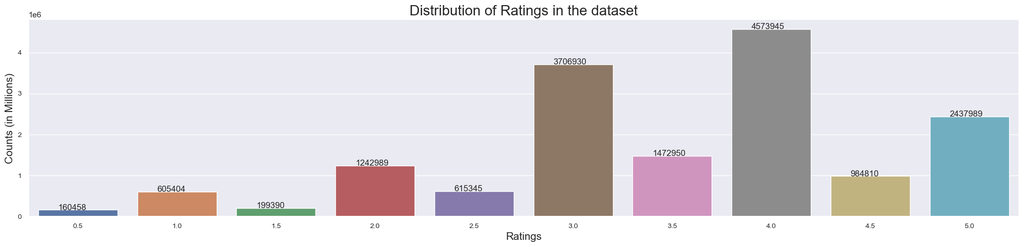

```python
import seaborn as sns
import matplotlib.pyplot as plt

# Set style for the plot
sns.set(style="darkgrid")

# Create a figure and axis
fig, axes = plt.subplots(1, 1, figsize=(25, 5), sharey=True)

# Plot countplot for 'rating' in Train_Data, specifying 'x=' for the rating column
sns.countplot(x="rating", data=Train_Data, ax=axes)

# Annotate the bars with their height values
for p in axes.patches:
    axes.annotate(f'{int(p.get_height())}', (p.get_x() + 0.2, p.get_height() + 100))

# Customize the plot labels
plt.tick_params(labelsize=15)
plt.title("Distribution of Ratings in the dataset", fontsize=20)
plt.xlabel("Ratings", fontsize=15)
plt.ylabel("Counts (in Millions)", fontsize=15)
plt.xticks(fontsize=10)
plt.yticks(fontsize=10)

# Show the plot
plt.show()
```

Observations:

1. The distribution of ratings seems to be similar as before.
2. The mean and median value are very close to around 3.5.

##### **2. Analyzing the number of ratings with date.**

```python
# Extracting the day of week from the date when rating was provided

Train_Data["date"] = pd.to_datetime(Train_Data["date"], errors='coerce')
Train_Data["DayOfWeek"] = Train_Data["date"].dt.strftime('%A')
Train_Data["Weekday"] = Train_Data["date"].apply(lambda x : 1 if x.dayofweek > 5 else 0)
```

```python
# Converting the number into 'Ks.

def ChangingLabelsInK(number):
    return str(int(number/10**3)) + "K"
```

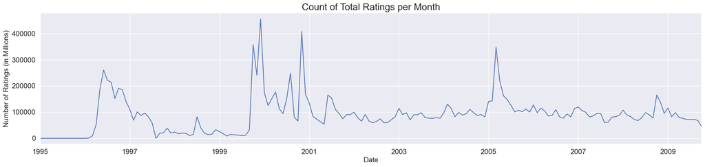

```python
import seaborn as sns
import matplotlib.pyplot as plt
import pandas as pd

# Ensure the 'date' column is in datetime format
Train_Data['date'] = pd.to_datetime(Train_Data['date'])

# Set style for the plot
sns.set(style="darkgrid")

# Create a figure and axis
fig, axes = plt.subplots(1, 1, figsize=(25, 5), sharey=True)

# Resample the data by month end and count the ratings (using 'ME' for month-end)
axes = Train_Data.resample("ME", on="date")["rating"].count().plot()

# Customize the plot with title and labels
axes.set_title("Count of Total Ratings per Month", fontsize=20)
axes.set_xlabel("Date", fontsize=15)
axes.set_ylabel("Number of Ratings (in Millions)", fontsize=15)

# Customize tick labels (optional, but ensure it works with the current tick locations)
axes.tick_params(labelsize=15)

# Show the plot
plt.show()
```

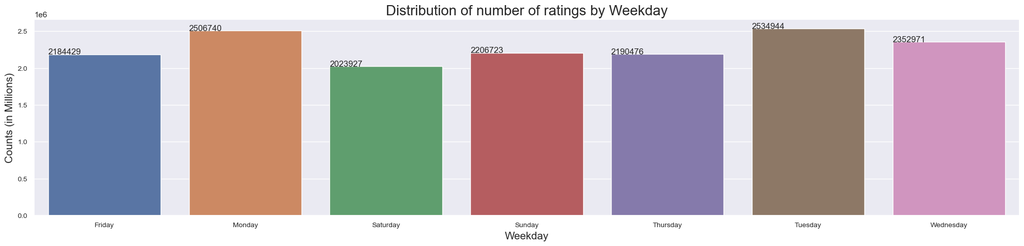

```python
import seaborn as sns
import matplotlib.pyplot as plt
import pandas as pd

# Ensure the 'date' column is in datetime format
Train_Data['date'] = pd.to_datetime(Train_Data['date'])

# Add a 'Weekday' column to the DataFrame (0 = Monday, 6 = Sunday)
Train_Data['Weekday'] = Train_Data['date'].dt.day_name()

# Group by 'Weekday' and count the number of ratings (this counts the number of ratings per weekday)
weekday_rating_count = Train_Data.groupby('Weekday')['rating'].count().reset_index()

# Set style for the plot
sns.set(style="darkgrid")

# Create the barplot for ratings by weekday
fig, axes = plt.subplots(1, 1, figsize=(25, 5), sharey=True)

# Create the barplot
sns.barplot(x="Weekday", y="rating", data=weekday_rating_count, ax=axes)

# Annotate each bar with the count value
for p in axes.patches:
    axes.annotate(f'{int(p.get_height())}', (p.get_x(), p.get_height() + 100))

# Update plot title and axis labels
plt.tick_params(labelsize=15)
plt.title("Distribution of number of ratings by Weekday", fontsize=20)
plt.xlabel("Weekday", fontsize=15)
plt.xticks(fontsize=10)
plt.yticks(fontsize=10)
plt.ylabel("Counts (in Millions)", fontsize=15)

# Display the plot
plt.show()
```

[figure not shown]

```python
import matplotlib.ticker as ticker

# Ensure 'date' column is in datetime format
Train_Data['date'] = pd.to_datetime(Train_Data['date'])

# Create a new 'DayOfWeek' column that extracts the day of the week
Train_Data['DayOfWeek'] = Train_Data['date'].dt.day_name()

# Now group by the 'DayOfWeek' and count the ratings
sns.set(style="darkgrid")
fig, axes = plt.subplots(1, 1, figsize=(25, 5), sharey=True)

sns.barplot(x="DayOfWeek", y="rating", data=Train_Data.groupby(by=["DayOfWeek"], as_index=False)["rating"].count(), ax=axes)

# Add annotations on top of each bar
for p in axes.patches:
    axes.annotate('{}'.format(int(p.get_height())), (p.get_x(), p.get_height() + 100))

# Use MaxNLocator to control the number of y-axis ticks
axes.yaxis.set_major_locator(ticker.MaxNLocator(integer=True))

# Set y-axis tick labels manually, after setting the ticks
yticks = axes.get_yticks()
axes.set_yticks(yticks)  # Set ticks explicitly
axes.set_yticklabels([changingLabels(num) for num in yticks])  # Set custom labels

plt.tick_params(labelsize=15)
plt.title("Distribution of number of ratings by individual days", fontsize=20)
plt.xlabel("Days", fontsize=15)
plt.xticks(fontsize=10)
plt.yticks(fontsize=10)
plt.ylabel("Counts (in Millions)", fontsize=15)
plt.show()
```

##### **3. Analyzing the average ratings by date.**

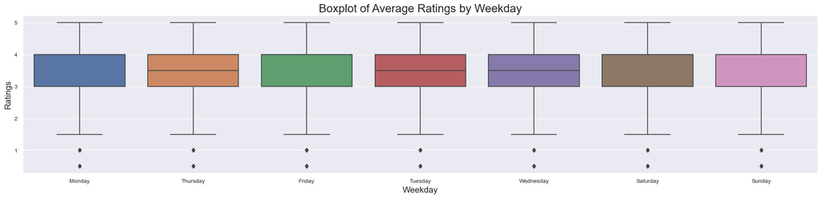

```python
# Visualizing the average ratings by weekday

sns.set(style="darkgrid")
fig, axes = plt.subplots(1, 1, figsize=(25, 5), sharey=True)

sns.boxplot(x="Weekday", y="rating" , data=Train_Data, ax=axes)

plt.tick_params(labelsize = 15)
plt.title("Boxplot of Average Ratings by Weekday", fontsize = 20)
plt.xlabel("Weekday", fontsize = 15)
plt.xticks(fontsize=10)
plt.ylabel("Ratings", fontsize = 15)
plt.yticks(fontsize=10)
plt.show()
```

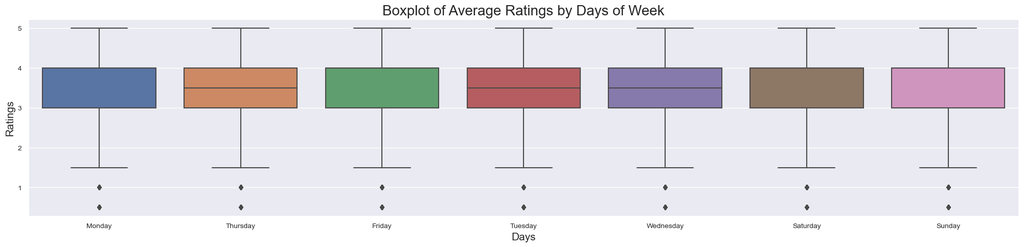

```python
# Visualizing the average ratings by individual Days of the Week

sns.set(style="darkgrid")
fig, axes = plt.subplots(1, 1, figsize=(25, 5), sharey=True)

sns.boxplot(x="DayOfWeek", y="rating", data=Train_Data, ax=axes)

plt.tick_params(labelsize = 15)
plt.title("Boxplot of Average Ratings by Days of Week", fontsize = 20)
plt.xlabel("Days", fontsize = 15)
plt.xticks(fontsize=10)
plt.ylabel("Ratings", fontsize = 15)
plt.yticks(fontsize=10)
plt.show()
```

Observations:

1. The average ratings given by the user does not seem to differ by weekday and weekends.
2. Even when we plot the average ratings by individual days, they seem to be similar for all the individual days.

##### **4. Analyzing the Ratings given by Users.**

```python
# Calculating the number of ratings given by individual users

no_of_rated_movies_per_user = Train_Data.groupby(by=["userId"], as_index=False)["rating"].count().sort_values(by="rating", ascending=False)
no_of_rated_movies_per_user.reset_index(drop=True, inplace=True)
```

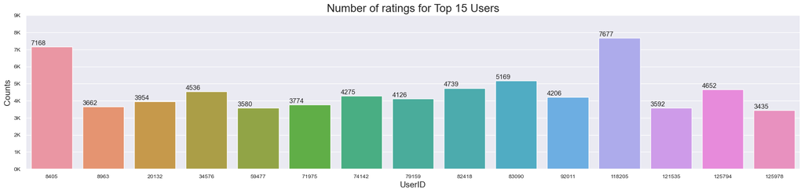

```python
import matplotlib.ticker as ticker

# Assuming no_of_rated_movies_per_user is already defined, which contains the number of ratings per user
sns.set(style="darkgrid")
fig, axes = plt.subplots(1, 1, figsize=(25, 5), sharey=True)

# Plot the bar chart for the top 15 users
sns.barplot(x="userId", y="rating", data=no_of_rated_movies_per_user[:15], ax=axes)

# Add annotations on top of each bar
for p in axes.patches:
    axes.annotate('{}'.format(int(p.get_height())), (p.get_x(), p.get_height() + 100))

# Use MaxNLocator to control the number of y-axis ticks
axes.yaxis.set_major_locator(ticker.MaxNLocator(integer=True))

# Set y-axis tick labels manually, after setting the ticks
yticks = axes.get_yticks()
axes.set_yticks(yticks)  # Set ticks explicitly
axes.set_yticklabels([ChangingLabelsInK(num) for num in yticks])  # Set custom labels

plt.tick_params(labelsize=15)
plt.title("Number of ratings for Top 15 Users", fontsize=20)
plt.xlabel("UserID", fontsize=15)
plt.xticks(fontsize=10)
plt.yticks(fontsize=10)
plt.ylabel("Counts", fontsize=15)
plt.show()
```

```python
# Checking the basic statistics for the number of ratings per user

print("Information about no. of ratings by users : \n", no_of_rated_movies_per_user["rating"].describe())
```

```
Information about no. of ratings by users :
 count    112466.000000
mean        142.267085
std         214.808118
min           1.000000
25%          35.000000
50%          69.000000
75%         155.000000
max        7677.000000
Name: rating, dtype: float64
```

```python
quantiles = no_of_rated_movies_per_user["rating"].quantile(np.arange(0.9, 1.01,0.01))
qvalue = np.arange(0.9, 1.01,0.01)
for ctr in qvalue:
    print("The {}th quantile value is : {}".format(int(ctr*100), quantiles[ctr]))
```

```
The 90th quantile value is : 333.0
The 91th quantile value is : 358.0
The 92th quantile value is : 386.0
The 93th quantile value is : 418.0
The 94th quantile value is : 459.0
The 95th quantile value is : 510.0
The 96th quantile value is : 573.0
The 97th quantile value is : 664.0
The 98th quantile value is : 804.7000000000116
The 99th quantile value is : 1060.3500000000058
The 100th quantile value is : 7677.0
```

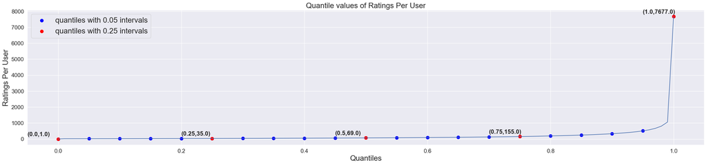

```python
# Plotting the quantile values

quantiles = no_of_rated_movies_per_user["rating"].quantile(np.arange(0, 1.01,0.01))

fig = plt.figure(figsize = (25, 5))

axes = fig.add_axes([0.1,0.1,1,1])
axes.set_title("Quantile values of Ratings Per User", fontsize = 20)
axes.set_xlabel("Quantiles", fontsize = 20)
axes.set_ylabel("Ratings Per User", fontsize = 20)
axes.plot(quantiles)

plt.scatter(x = quantiles.index[::5], y = quantiles.values[::5], c = "blue", s = 70, label="quantiles with 0.05 intervals")
plt.scatter(x = quantiles.index[::25], y = quantiles.values[::25], c = "red", s = 70, label="quantiles with 0.25 intervals")
plt.legend(loc='upper left', fontsize = 20)

for x, y in zip(quantiles.index[::25], quantiles.values[::25]):
    plt.annotate('({},{})'.format(x, y), xy = (x, y), fontweight='bold', fontsize = 16, xytext=(x-0.05, y+180))

axes.tick_params(labelsize = 15)
```

```python
# Calculating average ratings given by individual users

avg_ratings_per_user = Train_Data.groupby(by = ["userId"], as_index=False)["rating"].mean()
avg_ratings_per_user = avg_ratings_per_user.reset_index(drop=True)
avg_ratings_per_user = avg_ratings_per_user.merge(no_of_rated_movies_per_user[["userId", "rating"]], how="left", on="userId")
avg_ratings_per_user.rename(columns={"rating_x":"avg_rating", "rating_y": "num_of_rating"}, inplace=True)
avg_ratings_per_user = avg_ratings_per_user.sort_values("num_of_rating", ascending=False)
```

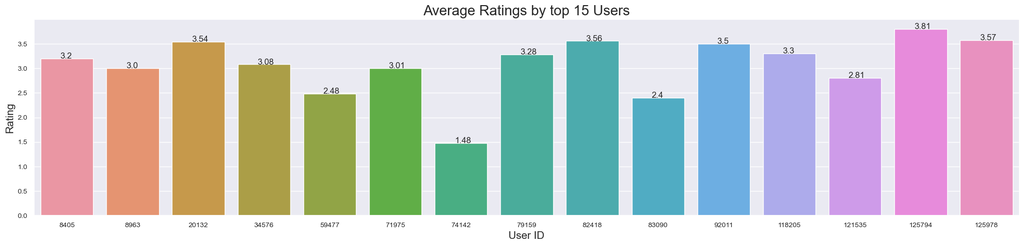

```python
# Visualizing the average ratings by individual Days of the Week

sns.set(style="darkgrid")
fig, axes = plt.subplots(1, 1, figsize=(25, 5), sharey=True)

sns.barplot(x="userId", y="avg_rating", data=avg_ratings_per_user[:15], ax=axes)

for p in axes.patches:
    axes.annotate('{}'.format(round(p.get_height(), 2)), (p.get_x()+0.3, p.get_height()))

plt.tick_params(labelsize = 15)
plt.title("Average Ratings by top 15 Users", fontsize = 20)
plt.xlabel("User ID", fontsize = 15)
plt.xticks(fontsize=10)
plt.ylabel("Rating", fontsize = 15)
plt.yticks(fontsize=10)
plt.show()
```

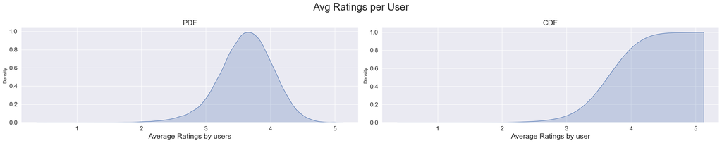

```python
# Replace inf values with NaN
# Replace inf values with NaN to avoid warnings
import warnings
warnings.filterwarnings("ignore", category=FutureWarning, message="use_inf_as_na option is deprecated")

avg_ratings_per_user["avg_rating"].replace([np.inf, -np.inf], np.nan, inplace=True)

# Now proceed with the KDE plots
sns.set(style="darkgrid")
fig, axes = plt.subplots(1, 2, figsize=(25, 5))
fig.suptitle("Avg Ratings per User", fontsize=25)

sns.kdeplot(avg_ratings_per_user["avg_rating"], ax=axes[0], label="PDF", fill=True)
axes[0].set_title("PDF", fontsize=18)
axes[0].set_xlabel("Average Ratings by users", fontsize=18)
axes[0].tick_params(labelsize=15)

sns.kdeplot(avg_ratings_per_user["avg_rating"], cumulative=True, ax=axes[1], fill=True, label="CDF")
axes[1].set_title("CDF", fontsize=18)
axes[1].set_xlabel("Average Ratings by user", fontsize=18)
axes[1].tick_params(labelsize=15)

fig.subplots_adjust(wspace=2)
plt.tight_layout()
plt.show()
```

Observations:

1. User ID 125794 has the highest avg. rating of 3.81.
2. The pdf of average ratings given by a user seems to be a bit left skewed, with most of the values centered around 3.5 to 4.
3. THe cdf also shows that avg. ratings is most frequent in between 3 to 5.

##### **5. Analyzing the Ratings given to the Movies.**

```python
import pandas as pd
import numpy as np

# Assuming Train_Data is the dataset you're working with
# Load Train_Data if necessary (example)
# Train_Data = pd.read_csv('train_data.csv')

# Check if 'movieId' and 'title' columns exist
if 'movieId' not in Train_Data.columns or 'title' not in Train_Data.columns:
    # If movieId or title is missing, we need to handle it

    # Case 1: If you have a separate movies dataset containing 'movieId' and 'title'
    try:
        # Load the movies dataset (assume it contains 'movieId' and 'title')
        movies_df = pd.read_csv('movies.csv')  # Replace with the correct file path
        Train_Data = Train_Data.merge(movies_df[['movieId', 'title']], on='movieId', how='left')
    except FileNotFoundError:
        print("Movies dataset not found. Proceeding with placeholder data.")

        # Case 2: If you don't have the movies dataset, generate dummy data for testing

        # Generate movieId if missing (creating a range of numbers)
        if 'movieId' not in Train_Data.columns:
            Train_Data['movieId'] = range(1, len(Train_Data) + 1)

        # Generate placeholder titles if missing
        if 'title' not in Train_Data.columns:
            Train_Data['title'] = ['Movie_' + str(i) for i in range(1, len(Train_Data) + 1)]

# After adding or merging movieId and title, calculate the count of ratings per movie
no_of_ratings_per_movie = Train_Data.groupby(by=["movieId", "title"], as_index=False)["rating"].count().sort_values(by=["rating"], ascending=False)

# Reset the index to clean up after grouping
no_of_ratings_per_movie = no_of_ratings_per_movie.reset_index(drop=True)

# Print the first few rows to check the result
print(no_of_ratings_per_movie.head())
```

```
   movieId                             title  rating
0      296               Pulp Fiction (1994)   55433
1      356               Forrest Gump (1994)   54873
2      593  Silence of the Lambs, The (1991)   53206
3      480              Jurassic Park (1993)   51905
4      318  Shawshank Redemption, The (1994)   49596
```

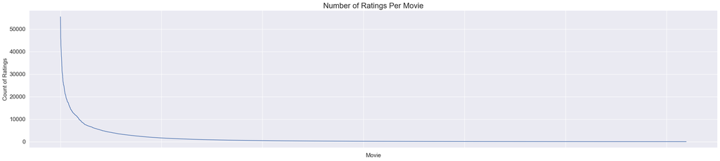

```python
# Visualizing the number of ratings for the movies

sns.set(style="darkgrid")

fig = plt.figure(figsize = (25, 5))
axes = fig.add_axes([0.1, 0.1, 1, 1])
plt.title("Number of Ratings Per Movie", fontsize = 20)
plt.xlabel("Movie", fontsize = 15)
plt.ylabel("Count of Ratings", fontsize = 15)

plt.plot(no_of_ratings_per_movie["rating"].values)

plt.tick_params(labelsize = 15)
axes.set_xticklabels([])
plt.show()
```

Observations:

1. It is quite clear that there are some movies which are very popular and were rated by many users as comapared to other movies which has caused the plot to be skewed.

[figure not shown]

```python
# Visualizing top 5 movies heavily rated movies.

import seaborn as sns
import matplotlib.pyplot as plt

# Assuming ChangingLabelsInK is a function you already defined for formatting labels

sns.set(style="darkgrid")
fig, axes = plt.subplots(1, 1, figsize=(25, 5), sharey=True)

# Create the bar plot
sns.barplot(x="title", y="rating", data=no_of_ratings_per_movie[:15], ax=axes)

# Annotate bars with the values
for p in axes.patches:
    axes.annotate('{}'.format(int(p.get_height())), (p.get_x(), p.get_height()+100))

# Set y-tick labels after defining y-ticks explicitly
axes.set_yticks(range(0, int(no_of_ratings_per_movie["rating"].max()), 1000))  # Adjust range and step as needed
axes.set_yticklabels([ChangingLabelsInK(num) for num in axes.get_yticks()])

# Customize the plot
plt.tick_params(labelsize=15)
plt.title("Number of Ratings for Top 15 Movies", fontsize=20)
plt.xlabel("Movie", fontsize=15)
plt.xticks(rotation=70, fontsize=10)
plt.ylabel("Counts", fontsize=15)
plt.yticks(fontsize=10)
plt.show()
```

```python
# Calculating average ratings for movies

avg_ratings_per_movie = Train_Data.groupby(by = ["movieId", "title"], as_index=False)["rating"].mean()
avg_ratings_per_movie = avg_ratings_per_movie.reset_index(drop=True)
avg_ratings_per_movie = avg_ratings_per_movie.merge(no_of_ratings_per_movie[["movieId", "rating"]], how="left", on="movieId")
avg_ratings_per_movie.rename(columns={"rating_x":"avg_rating", "rating_y": "num_of_rating"}, inplace=True)
avg_ratings_per_movie = avg_ratings_per_movie.sort_values("num_of_rating", ascending=False)
```

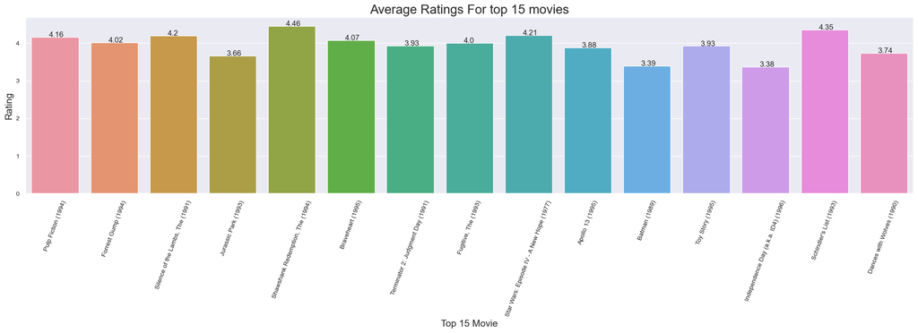

```python
# Visualizing the average ratings by individual Days of the Week

sns.set(style="darkgrid")
fig, axes = plt.subplots(1, 1, figsize=(25, 5), sharey=True)

sns.barplot(x="title", y="avg_rating", data=avg_ratings_per_movie[:15], ax=axes)

for p in axes.patches:
    axes.annotate('{}'.format(round(p.get_height(), 2)), (p.get_x()+0.3, p.get_height()))

plt.tick_params(labelsize = 15)
plt.title("Average Ratings For top 15 movies", fontsize = 20)
plt.xlabel("Top 15 Movie", fontsize = 15)
plt.xticks(rotation=70, fontsize=10)
plt.ylabel("Rating", fontsize = 15)
plt.yticks(fontsize=10)
plt.show()
```

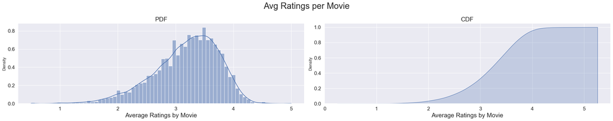

```python
import seaborn as sns
import matplotlib.pyplot as plt

# Set the style
sns.set(style="darkgrid")

# Create subplots
fig, axes = plt.subplots(1, 2, figsize=(25, 5))
fig.suptitle("Avg Ratings per Movie", fontsize=25)

# Plotting the PDF using histplot (axes-level function)
sns.histplot(avg_ratings_per_movie["avg_rating"], kde=True, ax=axes[0], label="PDF", stat="density")
axes[0].set_title("PDF", fontsize=18)
axes[0].set_xlabel("Average Ratings by Movie", fontsize=18)
axes[0].tick_params(labelsize=15)

# Plotting the CDF using kdeplot with fill=True
sns.kdeplot(avg_ratings_per_movie["avg_rating"], cumulative=True, ax=axes[1], fill=True, label="CDF")
axes[1].set_title("CDF", fontsize=18)
axes[1].set_xlabel("Average Ratings by Movie", fontsize=18)
axes[1].tick_params(labelsize=15)

# Adjust layout
fig.subplots_adjust(wspace=2)
plt.tight_layout()

# Show plot
plt.show()
```

Observations:

1. The distribution of average rating for movie is fairly normal one.
2. The cdf shows that the avg. rating is more frequent after 3.

# Conclusion :

# Summarized Conclusions

## 1. Users and Ratings Distribution

- There are over **138K unique users** in the dataset. User **118205** stands out with around **9K records**.
- The majority of ratings are concentrated between **3 and 5**, with most ratings being **3, 3.5, or 4**. The distribution is slightly **left-skewed**, indicating a preference for higher ratings.
- The **mean and median ratings** are approximately **3.5**.

## 3. Rating Trends Over Time

- Ratings span from **1995-01-09** to **2015-03-31**, with a notable spike of **91K+ ratings** on **2000-11-20**.
- High activity was observed in certain months between **1996–1998** and post-2000. Activity remained steady from **2001–2010**, with occasional spikes.
- Weekdays, particularly **Mondays and Tuesdays**, saw more ratings compared to weekends. However, the **average ratings** did not vary significantly by day.

## 6. Insights from Distribution and Patterns

- The overall distribution of ratings is **skewed towards higher values**, with average ratings frequently falling between **3 and 5**.
- The **popularity of certain movies** and **active user engagement** creates skewed patterns in the data.
- Despite the variation in user activity, the overall trends suggest a steady preference for **higher-rated movies**.